# Estadística descriptiva básica en R

Felipe Calvo Cepeda - fcalvoc@unal.edu.co | Universidad Nacional de Colombia

2023

## Instalamos paquetes

```r
# Paquetes para hacer resúmenes de conjuntos de datos
# install.packages("summarytools")
# install.packages("skimr")

# Paquete para estimar la moda de un vector univariado
# install.packages("modeest")

# Paquete para hacer diversas gráficas
# install.packages("ggpubr")
```

## Importar paquetes y datos

```r
library("tidyverse")
library("skimr")
library("summarytools")
library("modeest")
library("ggpubr")

## Lectura
read_delim(
  file = "data/Boston_Housing.txt",
  delim = "|",
  locale=locale(decimal_mark = ",")
) -> data_raw

## Revisar la estructura de los datos
str(data_raw)

## Convertimos variables respectivas a factores
factores <- c("CHAS","RAD")
data_raw %>% mutate_at(factores,factor) -> data

## Revisamos que la estructura de los datos esté ajustada
str(data)
```

## Estadísticos descriptivos frecuentes

```r
# Univariados
mean() # para la media
median() #para la mediana
modeest::mfv() # para la moda
var() # para la varianza
sd() # para la desviación estándar
max() # para el máximo
min() # para el mínimo
quantile() # para los cuartiles
IQR() # para el rango intercuartílico
# Multivariados
cov() # para la covarianza
cor() # para la correlación
table() # para tablas de contingencia - también sirve en una variable
```

### Ejemplo: estadísticos descriptivos para la variable AGE (cuantitativa)

```r
mean(data$AGE)
```

```
## [1] 68.5749
```

```r
median(data$AGE)
```

```
## [1] 77.5
```

```r
var(data$AGE)
```

```
## [1] 792.3584
```

```r
sd(data$AGE)
```

```
## [1] 28.14886
```

```r
max(data$AGE)
```

```
## [1] 100
```

```r
min(data$AGE)
```

```
## [1] 2.9
```

```r
quantile(data$AGE)
```

```
##      0%     25%     50%     75%    100%
##   2.900  45.025  77.500  94.075 100.000
```

```r
IQR(data$AGE)
```

```
## [1] 49.05
```

### Ejemplo: estadísticos descriptivos para la variable RAD (cualitativa)

```r
# Moda
mfv(data$RAD)
```

```
## [1] 24
## Levels: 1 2 3 4 5 6 7 8 24
```

```r
# Frecuencias absolutas (Conteos)
table(data$RAD)
```

```
##
##   1   2   3   4   5   6   7   8  24
##  20  24  38 110 115  26  17  24 132
```

```r
# Frecuencias relativas (Proporciones)
prop.table(table(data$RAD))
```

```
##
##          1          2          3          4          5          6          7
## 0.03952569 0.04743083 0.07509881 0.21739130 0.22727273 0.05138340 0.03359684
##          8         24
## 0.04743083 0.26086957
```

## Un método útil integrado en R: summary()

```r
## Resumen para una sola variable
summary(data$AGE)
```

```
##    Min. 1st Qu.  Median    Mean 3rd Qu.    Max.
##    2.90   45.02   77.50   68.57   94.08  100.00
```

```r
## Resumen para todo el conjunto de datos
summary(data)
```

```
##       CRIM                ZN             INDUS       CHAS         NOX
##  Min.   : 0.00632   Min.   :  0.00   Min.   : 0.46   0:471   Min.   :0.3850
##  1st Qu.: 0.08205   1st Qu.:  0.00   1st Qu.: 5.19   1: 35   1st Qu.:0.4490
##  Median : 0.25651   Median :  0.00   Median : 9.69           Median :0.5380
##  Mean   : 3.61352   Mean   : 11.36   Mean   :11.14           Mean   :0.5547
##  3rd Qu.: 3.67708   3rd Qu.: 12.50   3rd Qu.:18.10           3rd Qu.:0.6240
##  Max.   :88.97620   Max.   :100.00   Max.   :27.74           Max.   :0.8710
##
##        RM             AGE              DIS              RAD
##  Min.   :3.561   Min.   :  2.90   Min.   : 1.130   24     :132
##  1st Qu.:5.886   1st Qu.: 45.02   1st Qu.: 2.100   5      :115
##  Median :6.208   Median : 77.50   Median : 3.207   4      :110
##  Mean   :6.285   Mean   : 68.57   Mean   : 3.795   3      : 38
##  3rd Qu.:6.623   3rd Qu.: 94.08   3rd Qu.: 5.188   6      : 26
##  Max.   :8.780   Max.   :100.00   Max.   :12.127   2      : 24
##                                                    (Other): 61
##       TAX           PTRATIO            B              LSTAT
##  Min.   :187.0   Min.   :12.60   Min.   :  0.32   Min.   : 1.73
##  1st Qu.:279.0   1st Qu.:17.40   1st Qu.:375.38   1st Qu.: 6.95
##  Median :330.0   Median :19.05   Median :391.44   Median :11.36
##  Mean   :408.2   Mean   :18.46   Mean   :356.67   Mean   :12.65
##  3rd Qu.:666.0   3rd Qu.:20.20   3rd Qu.:396.23   3rd Qu.:16.95
##  Max.   :711.0   Max.   :22.00   Max.   :396.90   Max.   :37.97
##
##       MEDV
##  Min.   : 5.00
##  1st Qu.:17.02
##  Median :21.20
##  Mean   :22.53
##  3rd Qu.:25.00
##  Max.   :50.00
##
```

Normalmente estas funciones no trabajan si encuentran datos perdidos, para eliminar esta restricción se usa

```r
na.rm = TRUE

## Cálculo del promedio omitiendo datos perdidos/faltantes
mean(data$AGE, na.rm = TRUE)
```

## Otros métodos de resumen útiles

```r
# Resumen usando el paquete skimr
skim(data)
```

Data summary

| Name | data |
| --- | --- |
| Number of rows | 506 |
| Number of columns | 14 |
| _______________________ |  |
| Column type frequency: |  |
| factor | 2 |
| numeric | 12 |
| ________________________ |  |
| Group variables | None |

**Variable type: factor**

| skim_variable | n_missing | complete_rate | ordered | n_unique | top_counts |
| --- | --- | --- | --- | --- | --- |
| CHAS | 0 | 1 | FALSE | 2 | 0: 471, 1: 35 |
| RAD | 0 | 1 | FALSE | 9 | 24: 132, 5: 115, 4: 110, 3: 38 |

**Variable type: numeric**

| skim_variable | n_missing | complete_rate | mean | sd | p0 | p25 | p50 | p75 | p100 | hist |
| --- | --- | --- | --- | --- | --- | --- | --- | --- | --- | --- |
| CRIM | 0 | 1 | 3.61 | 8.60 | 0.01 | 0.08 | 0.26 | 3.68 | 88.98 | ▇▁▁▁▁ |
| ZN | 0 | 1 | 11.36 | 23.32 | 0.00 | 0.00 | 0.00 | 12.50 | 100.00 | ▇▁▁▁▁ |
| INDUS | 0 | 1 | 11.14 | 6.86 | 0.46 | 5.19 | 9.69 | 18.10 | 27.74 | ▇▆▁▇▁ |
| NOX | 0 | 1 | 0.55 | 0.12 | 0.38 | 0.45 | 0.54 | 0.62 | 0.87 | ▇▇▆▅▁ |
| RM | 0 | 1 | 6.28 | 0.70 | 3.56 | 5.89 | 6.21 | 6.62 | 8.78 | ▁▂▇▂▁ |
| AGE | 0 | 1 | 68.57 | 28.15 | 2.90 | 45.02 | 77.50 | 94.07 | 100.00 | ▂▂▂▃▇ |
| DIS | 0 | 1 | 3.80 | 2.11 | 1.13 | 2.10 | 3.21 | 5.19 | 12.13 | ▇▅▂▁▁ |
| TAX | 0 | 1 | 408.24 | 168.54 | 187.00 | 279.00 | 330.00 | 666.00 | 711.00 | ▇▇▃▁▇ |
| PTRATIO | 0 | 1 | 18.46 | 2.16 | 12.60 | 17.40 | 19.05 | 20.20 | 22.00 | ▁▃▅▅▇ |
| B | 0 | 1 | 356.67 | 91.29 | 0.32 | 375.38 | 391.44 | 396.22 | 396.90 | ▁▁▁▁▇ |
| LSTAT | 0 | 1 | 12.65 | 7.14 | 1.73 | 6.95 | 11.36 | 16.96 | 37.97 | ▇▇▅▂▁ |
| MEDV | 0 | 1 | 22.53 | 9.20 | 5.00 | 17.02 | 21.20 | 25.00 | 50.00 | ▂▇▅▁▁ |

```r
# Resumen usando el paquete summarytools
summarytools::descr(data)
```

```
## Descriptive Statistics
## data
## N: 506
##
##                        AGE        B     CRIM      DIS    INDUS    LSTAT     MEDV      NOX   PTRATIO
## ----------------- -------- -------- -------- -------- -------- -------- -------- -------- ---------
##              Mean    68.57   356.67     3.61     3.80    11.14    12.65    22.53     0.55     18.46
##           Std.Dev    28.15    91.29     8.60     2.11     6.86     7.14     9.20     0.12      2.16
##               Min     2.90     0.32     0.01     1.13     0.46     1.73     5.00     0.38     12.60
##                Q1    45.00   375.33     0.08     2.10     5.19     6.93    17.00     0.45     17.40
##            Median    77.50   391.44     0.26     3.21     9.69    11.36    21.20     0.54     19.05
##                Q3    94.10   396.23     3.68     5.21    18.10    16.96    25.00     0.62     20.20
##               Max   100.00   396.90    88.98    12.13    27.74    37.97    50.00     0.87     22.00
##               MAD    28.98     8.09     0.33     1.91     9.37     7.11     5.93     0.13      1.70
##               IQR    49.05    20.85     3.60     3.09    12.91    10.01     7.98     0.17      2.80
##                CV     0.41     0.26     2.38     0.55     0.62     0.56     0.41     0.21      0.12
##          Skewness    -0.60    -2.87     5.19     1.01     0.29     0.90     1.10     0.72     -0.80
##       SE.Skewness     0.11     0.11     0.11     0.11     0.11     0.11     0.11     0.11      0.11
##          Kurtosis    -0.98     7.10    36.60     0.46    -1.24     0.46     1.45    -0.09     -0.30
##           N.Valid   506.00   506.00   506.00   506.00   506.00   506.00   506.00   506.00    506.00
##         Pct.Valid   100.00   100.00   100.00   100.00   100.00   100.00   100.00   100.00    100.00
##
## Table: Table continues below
##
##
##
##                         RM      TAX       ZN
## ----------------- -------- -------- --------
##              Mean     6.28   408.24    11.36
##           Std.Dev     0.70   168.54    23.32
##               Min     3.56   187.00     0.00
##                Q1     5.88   279.00     0.00
##            Median     6.21   330.00     0.00
##                Q3     6.62   666.00    12.50
##               Max     8.78   711.00   100.00
##               MAD     0.51   108.23     0.00
##               IQR     0.74   387.00    12.50
##                CV     0.11     0.41     2.05
##          Skewness     0.40     0.67     2.21
##       SE.Skewness     0.11     0.11     0.11
##          Kurtosis     1.84    -1.15     3.95
##           N.Valid   506.00   506.00   506.00
##         Pct.Valid   100.00   100.00   100.00
```

## Gráficas básicas

### Diagrama de puntos

Presenta los valores de una variable para cada observación usando símbolos, y cada observación se grafica de manera relativa al número de la observación.

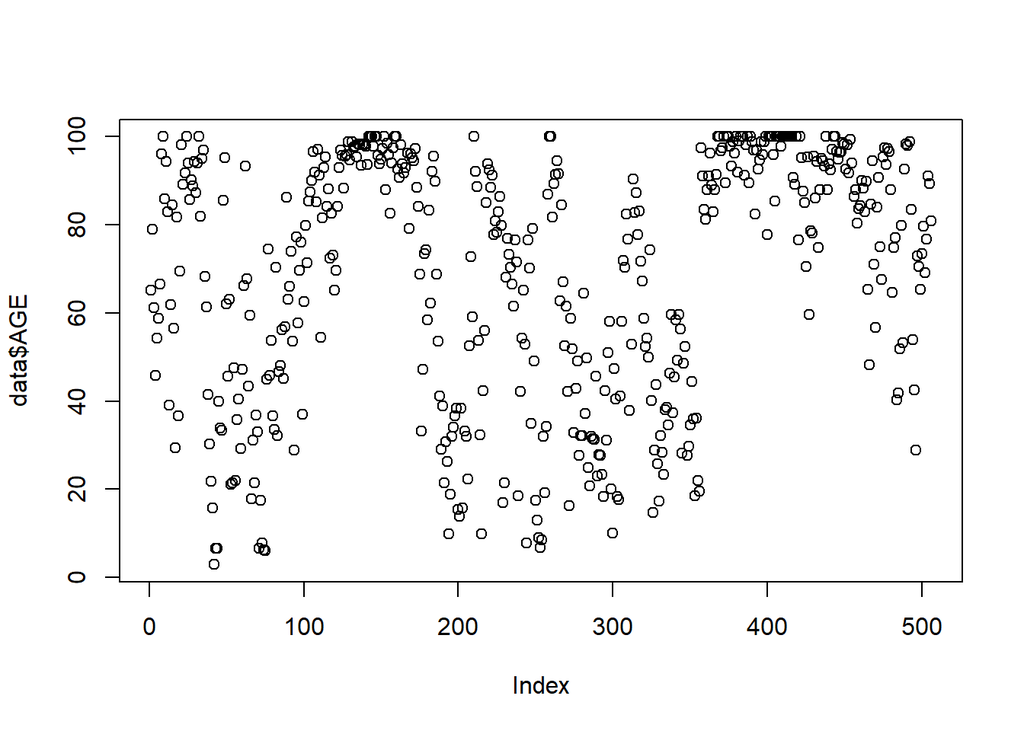

```r
plot(data$AGE)
```

### Histogramas

Es un tipo de gráfica de barras que muestra conteos o frecuencias relativas de valores que caen en diferentes intervalos.

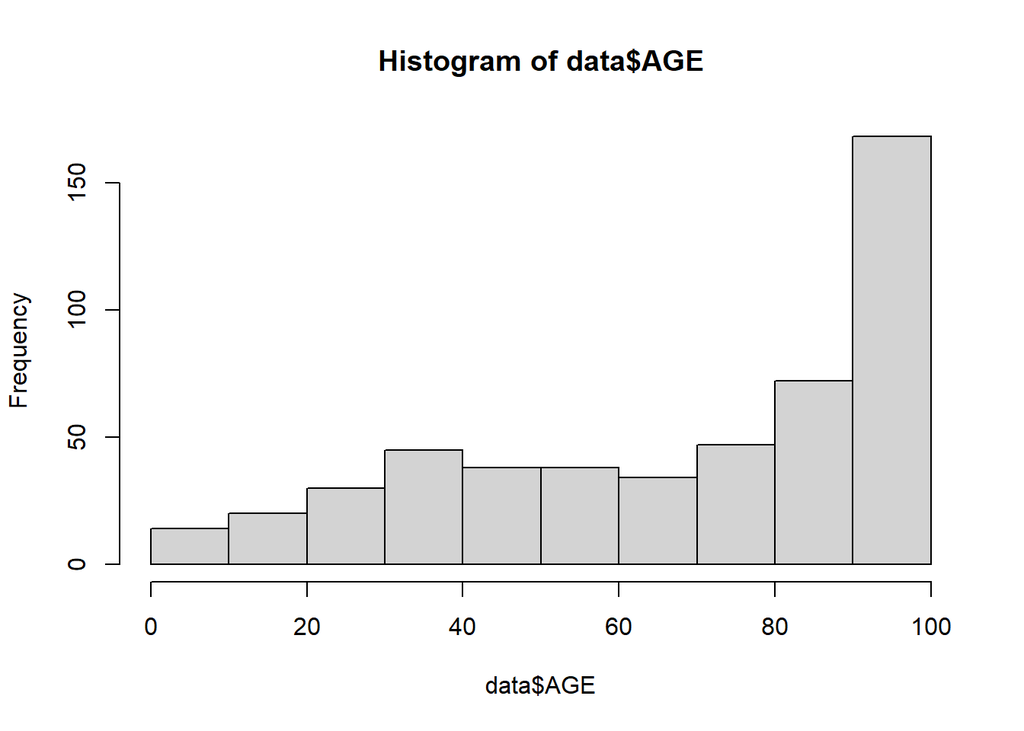

```r
hist(data$AGE)
```

Podemos cambiar el número de barras usando el parámetro **breaks**

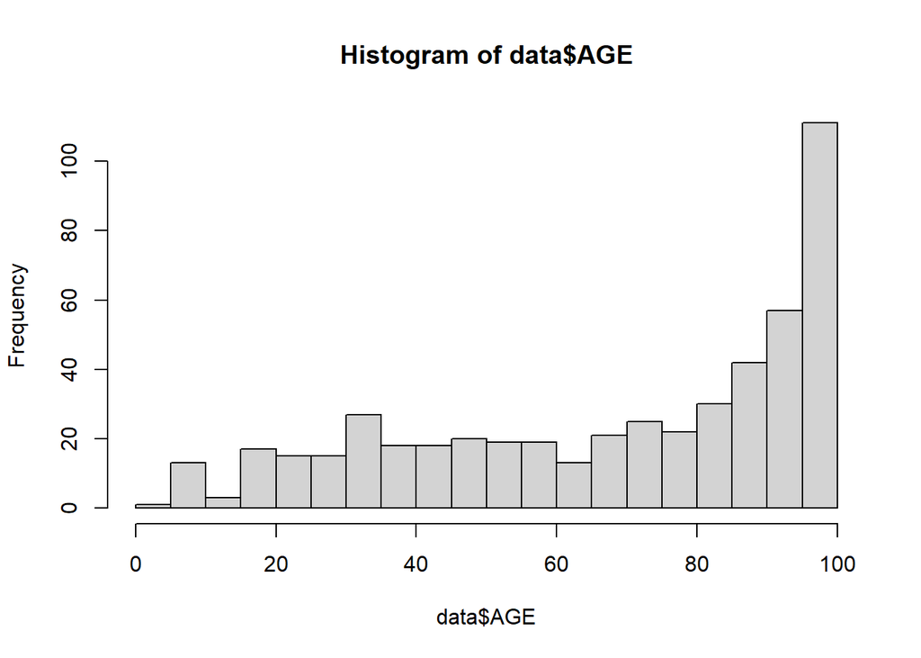

```r
hist(data$AGE, breaks=20)
```

### Gráficos de densidad (también llamados gráficas Kernel o histogramas suavizados)

Muestra las frecuencias relativas locales de los puntos a lo largo del eje X. En otras palabras, en los intervalos donde hay más puntos/observaciones la gráfica crece indicando mayor “densidad”.

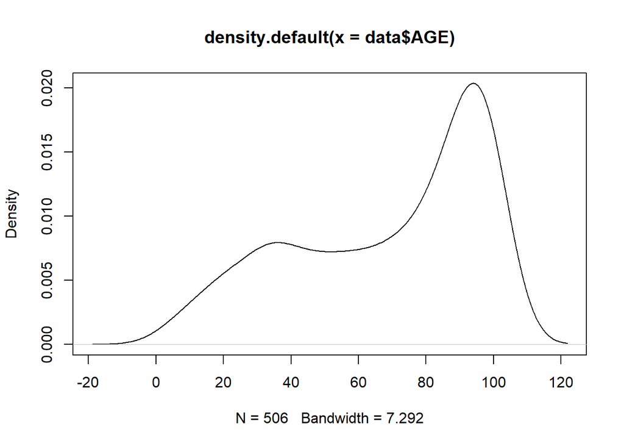

```r
plot(density(data$AGE))
```

> Los gráficos de densidad son muy útiles para determinar la función de distribución de probabilidad de una variable cuantitativa.

## Gráfico Q-Q

Se usa para revisar si los datos siguen una distribución aproximadamente normal.

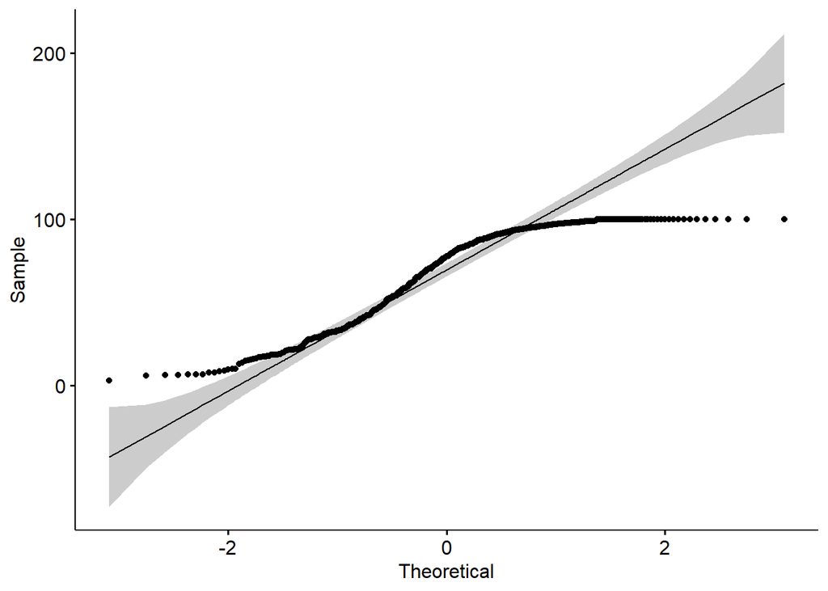

```r
ggqqplot(data, x = "AGE")
```

### Función de distribución empírica acumulada

Muestra la frecuencia relativa acumulada para los valores de la muestra.

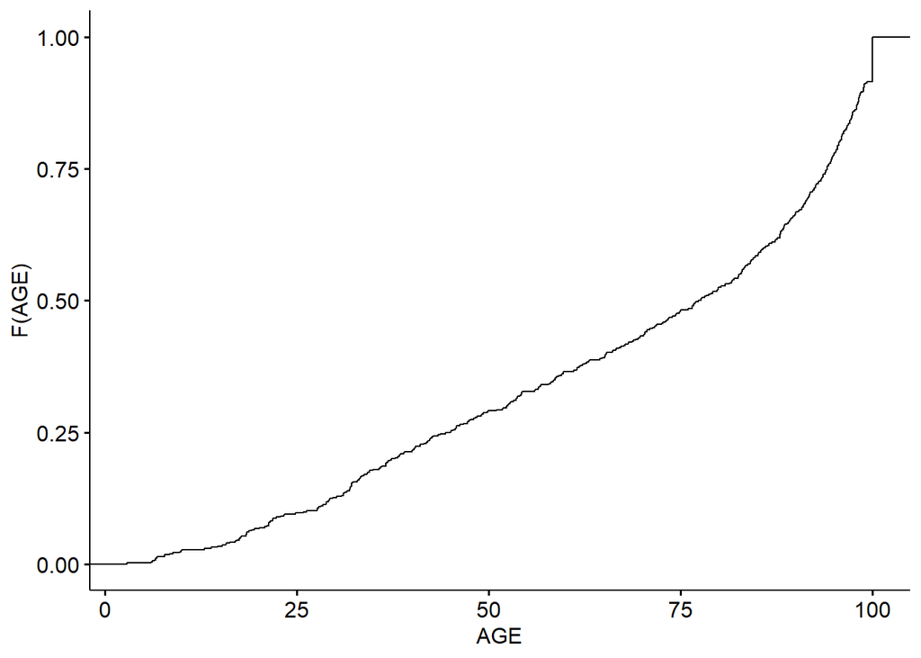

```r
ggecdf(data, x = "AGE")
```

### Boxplot

Muestra la ubicación, dispersión y distribución de una variable mediante la construcción de una figura en forma de caja con un conjunto de líneas (bigotes) que se extienden desde los extremos de la caja. Los bordes del cuadro se dibujan en los percentiles 25 y 75 de los datos, y una línea en el medio del cuadro marca el percentil 50.

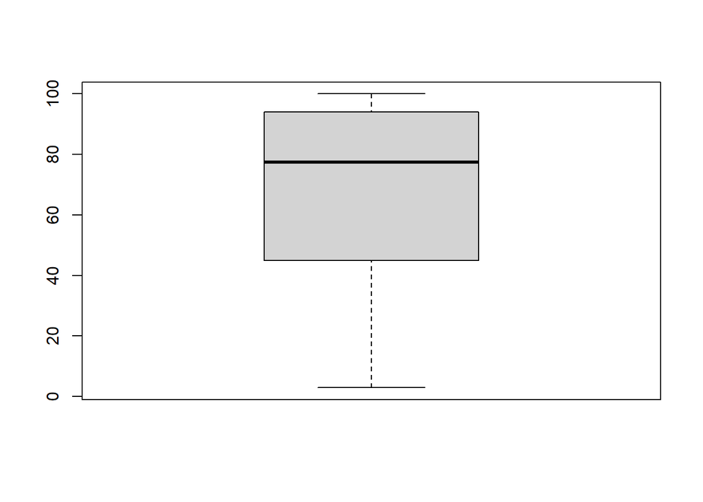

```r
boxplot(data$AGE)
```

### Diagrama de barras

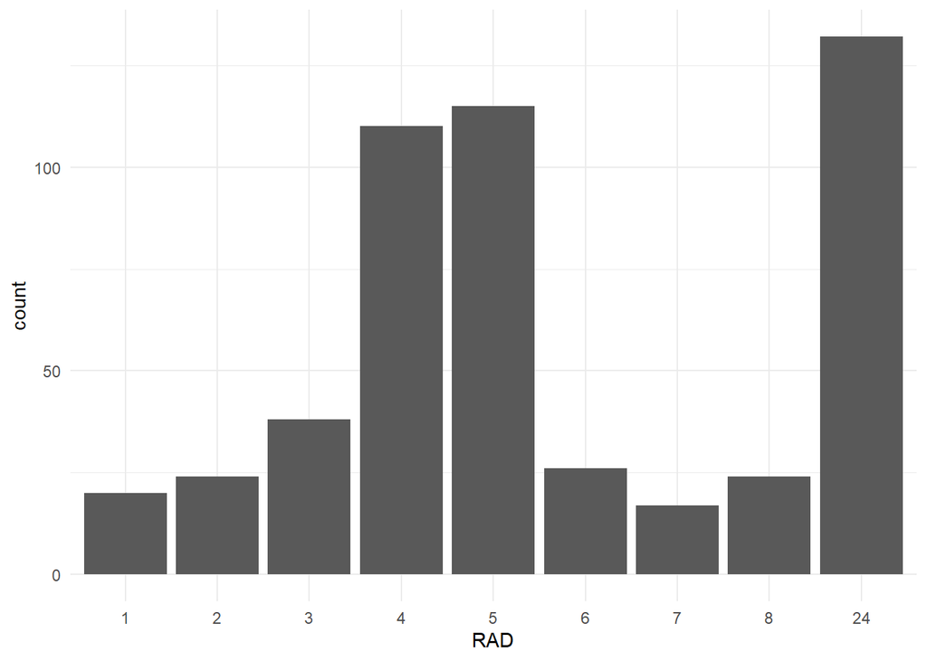

```r
# Sin orden
ggplot(data, aes(x = RAD))+
  geom_bar(stat="count")+
  theme_minimal()
```

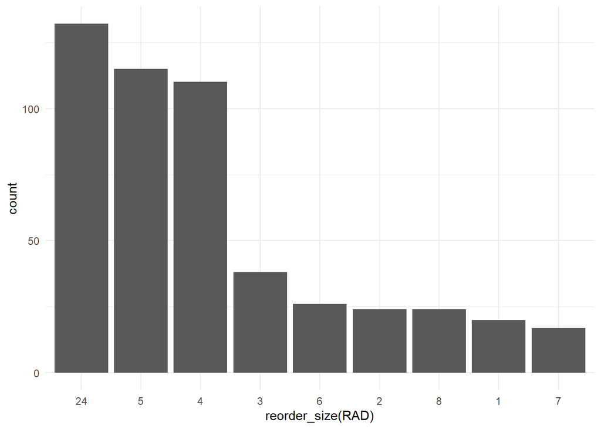

```r
# Ordenado
# Función para reordenar los factores de un vector en orden decreciente
reorder_size <- function(x) {
        factor(x, levels = names(sort(table(x), decreasing = TRUE)))
}
ggplot(data, aes(x = reorder_size(RAD)))+
  geom_bar(stat="count")+
  theme_minimal()
```

## Gráficos bivariados y multivariados

### Ejemplo: diagrama de dispersión entre dos variables contínuas

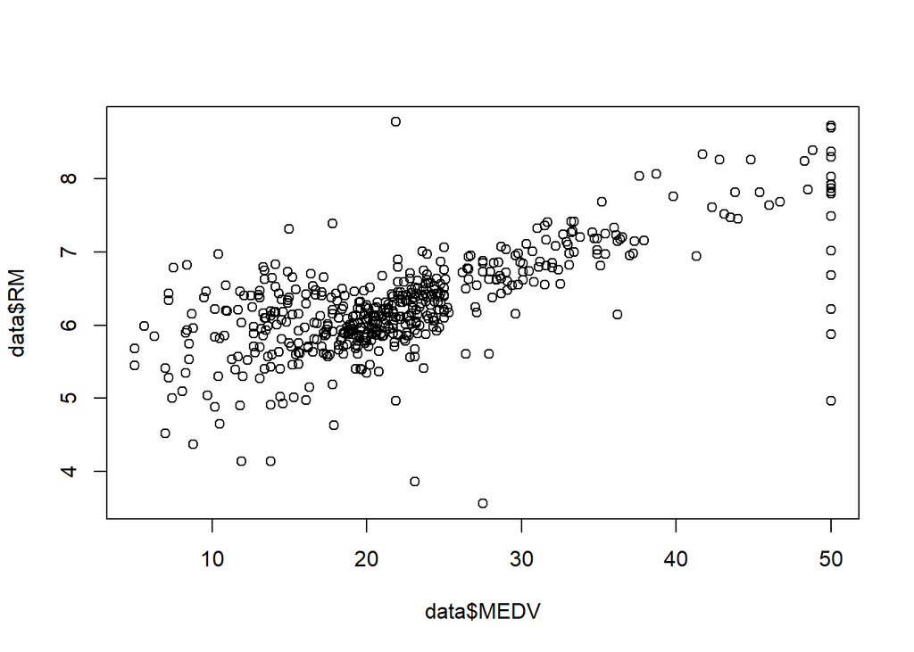

```r
plot(data$MEDV, data$RM)
```

### Ejemplo: boxplot por grupos (una variable contínua y una categórica)

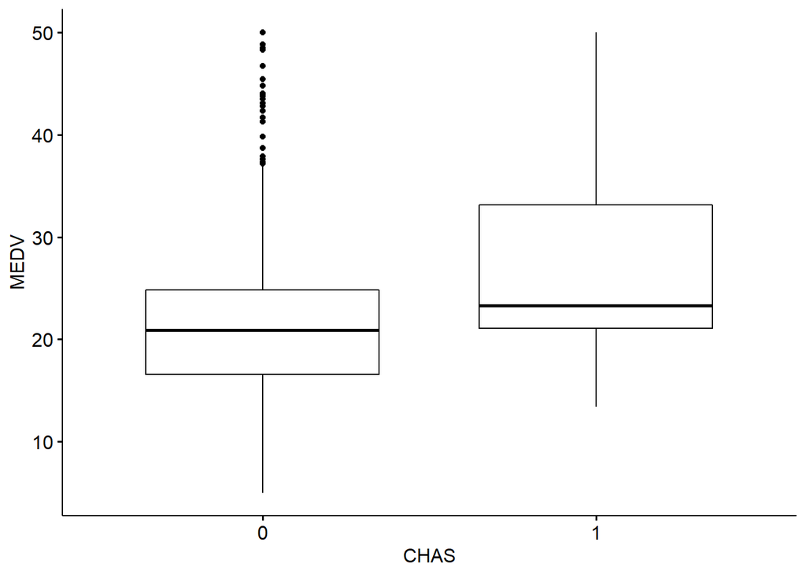

```r
ggboxplot(data, x = "CHAS", y = "MEDV",
          palette = c("#00AFBB", "#E7B800"))
```

### Ejemplo: matríz de correlación gráfica

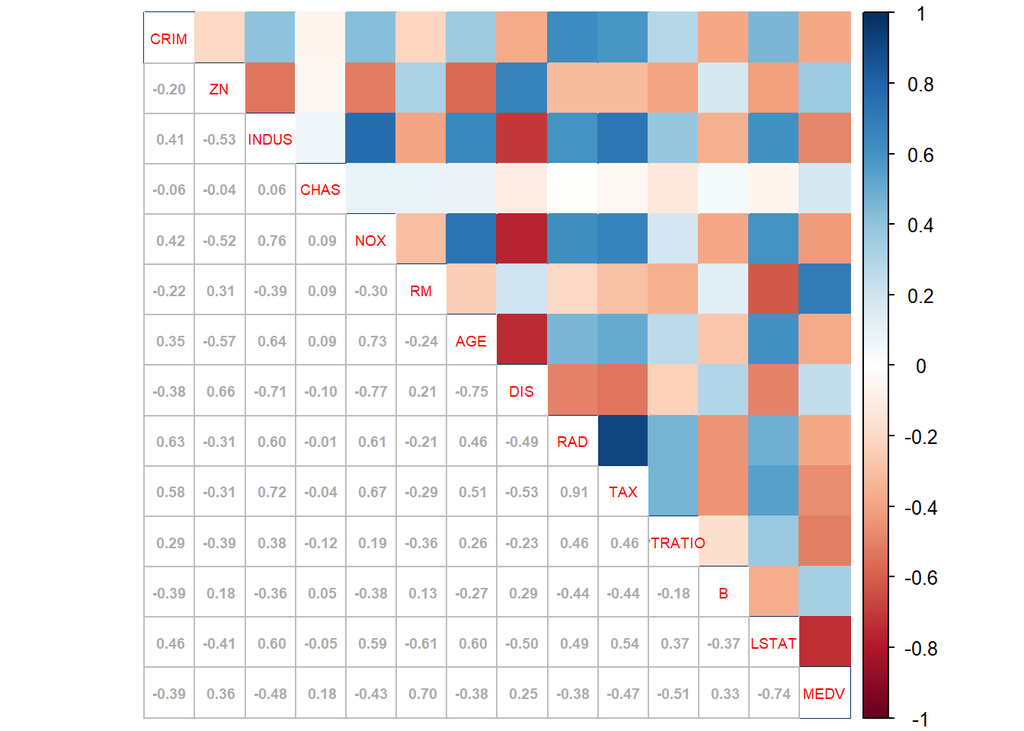

```r
library("corrplot")
data_raw %>%
  cor %>%
  corrplot.mixed(lower = "number", upper = "color", lower.col = "#aaaaaa", number.cex = 0.6, tl.cex = 0.6)
```

## Una librería útil con una interfaz para hacer gráficas: *esquisse*

```r
## Instalamos la librería
# install.packages("esquisse")

## Cargamos la librería
# library("esquisse")

## Llamamos a la función esquisser especificando con cuales datos queremos trabajar
# esquisser(data = data, viewer = "browser")
```

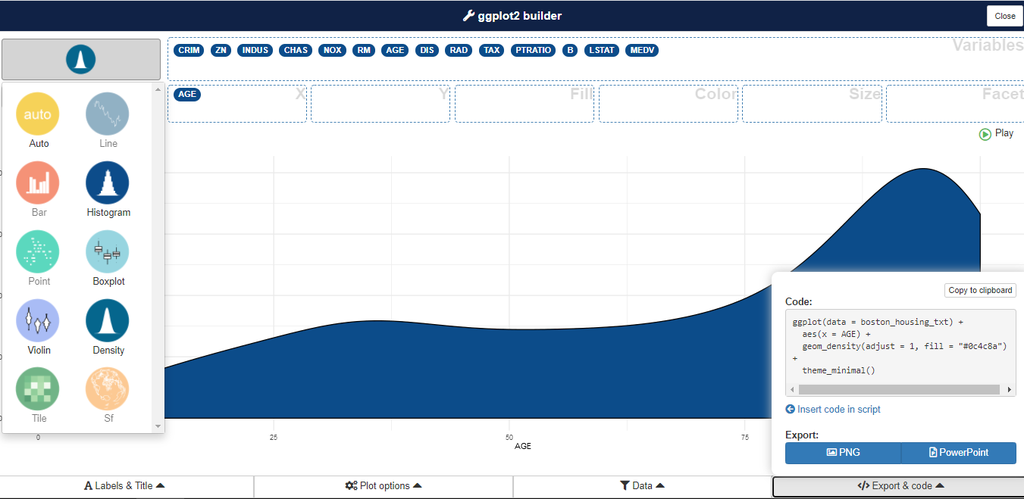

## Gráficos profesionales

- [Galería de gráficas en R](https://www.r-graph-gallery.com/)
- [Top 50 de visualizaciones en R](http://r-statistics.co/Top50-Ggplot2-Visualizations-MasterList-R-Code.html)

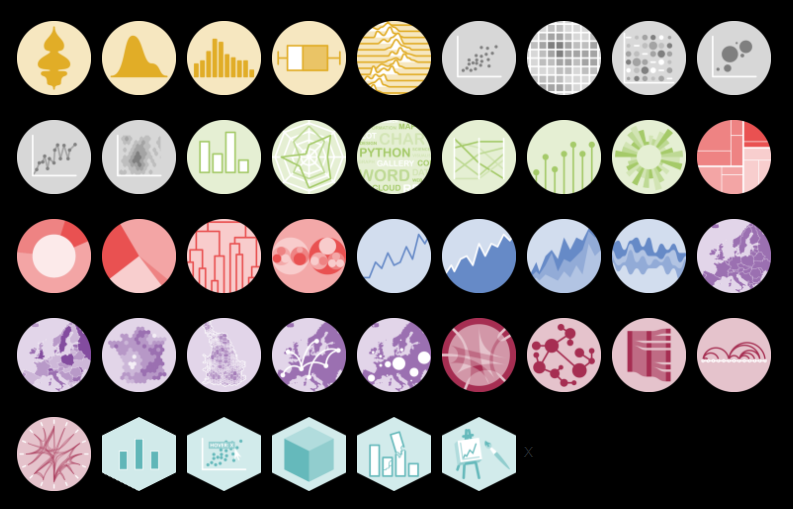